# HydroTGNN 튜토리얼: USGS 유량 데이터 → tsl 시공간 그래프 신경망

이 노트북은 이 저장소의 분석 코드가 **어떤 순서로, 어떤 객체를 거쳐** 동작하는지 단계별로 보여줍니다.

```
CSV (adj_matrix, discharge)
  → IJCNNHydrologyDataset   (pandas 기반, tsl TabularDataset)      ... 2~4절
  → get_connectivity()       (인접행렬 → edge_index / edge_weight)   ... 4절
  → add_missing_values()     (결측 마스크: mask / eval_mask)          ... 5절
  → ImputationDataset        (torch 기반, 슬라이딩 윈도우 샘플)       ... 6절
  → SpatioTemporalDataModule (스케일링 + train/val/test 분할)        ... 7절
  → Imputer + GRINModel      (LightningModule + 학습)               ... 8절
  → 평가/시각화                                                     ... 9절
  → (보너스) 예측(forecasting) 파이프라인                           ... 10절
  → Hydra 설정(spin_hydrology.yaml)과의 연결                        ... 11절
```

> 실제 USGS 데이터(`IJCNN/adj_matrix.csv`, `IJCNN/merged_discharge_data.csv`)는 저장소에 포함되어 있지 않습니다. 여기서는 **같은 파일 형식의 합성 하천망 데이터**를 만들어 사용합니다. 실제 데이터가 있으면 2절의 경로만 바꾸면 됩니다.

실행 환경: conda env `hydrotgnn` (PyTorch + PyG + Lightning + `pip install -e tsl[experiment]`).

## 1. 환경 확인

```python
import os, sys, warnings
warnings.filterwarnings("ignore")

import numpy as np
import pandas as pd
import torch
import matplotlib.pyplot as plt

import tsl

# 한글 폰트 설정 (없으면 그래프의 한글이 □ 로 깨집니다)
from matplotlib import font_manager
_ko_fonts = [f.name for f in font_manager.fontManager.ttflist
             if any(k in f.name for k in ("NanumGothic", "NanumBarunGothic", "Noto Sans CJK KR", "Malgun Gothic", "AppleGothic"))]
if _ko_fonts:
    plt.rcParams["font.family"] = sorted(set(_ko_fonts), key=lambda n: n != "NanumGothic")[0]
else:
    print("경고: 한글 폰트를 찾지 못했습니다. `sudo apt install fonts-nanum` 후 커널을 재시작하세요.")
plt.rcParams["axes.unicode_minus"] = False       # 마이너스 기호 깨짐 방지
print("font   :", plt.rcParams["font.family"])

print("python :", sys.version.split()[0])
print("torch  :", torch.__version__, "| cuda:", torch.cuda.is_available())
print("tsl    :", tsl.__version__, "|", os.path.dirname(tsl.__file__))

# 이 노트북은 저장소 루트에서 실행한다고 가정합니다.
REPO = os.getcwd()
assert os.path.exists(os.path.join(REPO, "hydrology_dataset.py")), "저장소 루트에서 실행하세요"
sys.path.insert(0, REPO)
```

```
font   : ['NanumGothic']
python : 3.11.16
torch  : 2.11.0+cu128 | cuda: True
tsl    : 0.9.6 | /home/hydro/research/gnn/HydroTGNN/tsl/tsl
```

## 2. 합성 하천망 데이터 만들기

`IJCNNHydrologyDataset`이 기대하는 두 CSV의 형식:

| 파일 | 형식 |
| --- | --- |
| `adj_matrix.csv` | `N x N` 정방행렬, 첫 열은 인덱스(관측소 ID). `a[i, j] > 0` 이면 i → j 로 물이 흐름(상류 → 하류). |
| `merged_discharge_data.csv` | 행 = 시간, 열 = 관측소 ID, 첫 열은 datetime 인덱스. 값 = 유량(discharge). 결측은 `NaN`. |

아래는 8개 관측소로 이루어진 작은 나무 모양의 하천망입니다. 하류 유량 = 상류 유량의 합(지연 포함) + 자체 유역 유출.

```python
rng = np.random.default_rng(0)

# 하천망 위상: (상류 -> 하류)
gauges = [f"G{i:02d}" for i in range(8)]
edges = [(0, 2), (1, 2), (2, 4), (3, 4), (4, 6), (5, 6), (6, 7)]   # G07이 최하류 출구

N = len(gauges)
adj = np.zeros((N, N), dtype=int)
for u, v in edges:
    adj[u, v] = 1

T = 24 * 120                                   # 120일치 시간별 데이터
index = pd.date_range("2021-03-01", periods=T, freq="h")
t = np.arange(T)

# 1) 각 유역의 자체 유출: 기저유량 + 강우 이벤트에 대한 지수 감쇠 응답
def local_runoff(seed, base, n_events):
    r = np.random.default_rng(seed)
    q = np.full(T, base, dtype=float)
    for _ in range(n_events):
        start = r.integers(0, T - 72)
        peak = r.uniform(2, 8) * base
        q[start:start + 72] += peak * np.exp(-np.arange(72) / r.uniform(8, 20))
    q *= 1 + 0.15 * np.sin(2 * np.pi * t / 24)       # 일주기(눈 녹음 등) 흉내
    return q

local = {i: local_runoff(100 + i, base=rng.uniform(5, 15), n_events=12) for i in range(N)}

# 2) 라우팅: 상류에서 하류로 위상 정렬 순서대로 누적 (한 링크당 3시간 지연)
order = [0, 1, 3, 5, 2, 4, 6, 7]
Q = {i: local[i].copy() for i in range(N)}
for v in order:
    for u in range(N):
        if adj[u, v]:
            Q[v] += np.roll(Q[u], 3)
discharge = pd.DataFrame({g: Q[i] for i, g in enumerate(gauges)}, index=index)
discharge += rng.normal(0, 0.3, discharge.shape)          # 센서 잡음

# 3) 실제 USGS 데이터처럼 원본에도 결측(센서 다운타임)을 조금 넣어 둔다
for g in rng.choice(gauges, 3, replace=False):
    s = rng.integers(0, T - 48)
    discharge.loc[discharge.index[s:s + 48], g] = np.nan

DATA_DIR = os.path.join(REPO, "data", "synthetic")
os.makedirs(DATA_DIR, exist_ok=True)
ADJ_PATH = os.path.join(DATA_DIR, "adj_matrix.csv")
DIS_PATH = os.path.join(DATA_DIR, "merged_discharge_data.csv")
pd.DataFrame(adj, index=gauges, columns=gauges).to_csv(ADJ_PATH)
discharge.to_csv(DIS_PATH, index_label="datetime")

print(discharge.shape, "| NaN:", int(discharge.isna().sum().sum()))
discharge.head()
```

```
(2880, 8) | NaN: 144
```

|  | G00 | G01 | G02 | G03 | G04 | G05 | G06 | G07 |
| --- | --- | --- | --- | --- | --- | --- | --- | --- |
| 2021-03-01 00:00:00 | 11.158496 | 7.318241 | 22.267825 | 5.177674 | 38.095917 | 14.061918 | 61.975444 | 74.819446 |
| 2021-03-01 01:00:00 | 11.647740 | 7.901830 | 23.380668 | 5.678561 | 39.690694 | 15.085967 | 62.956761 | 75.008547 |
| 2021-03-01 02:00:00 | 12.493379 | 8.303411 | 23.919645 | 5.276154 | 40.735342 | 15.253181 | 63.301481 | 75.152109 |
| 2021-03-01 03:00:00 | 12.527779 | 8.676603 | 25.115406 | 5.819748 | 41.949571 | 15.587125 | 65.396297 | 76.396290 |
| 2021-03-01 04:00:00 | 12.468854 | 9.152027 | 26.323981 | 6.070659 | 43.541014 | 15.868602 | 67.346609 | 77.636526 |

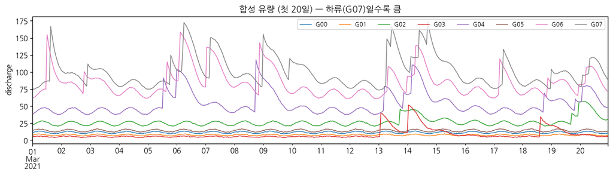

```python
fig, ax = plt.subplots(figsize=(12, 3.5))
discharge.iloc[: 24 * 20].plot(ax=ax, lw=1)
ax.set_ylabel("discharge"); ax.set_title("합성 유량 (첫 20일) — 하류(G07)일수록 큼")
ax.legend(ncol=8, fontsize=8); plt.tight_layout(); plt.show()
```

## 3. `IJCNNHydrologyDataset` 로드하기

`hydrology_dataset.py`의 클래스는 tsl의 `TabularDataset`을 상속합니다. 생성자에서 `load_data()`가 호출되어

1. 두 CSV를 읽고 노드 수를 맞추고(불일치 시 앞쪽 `min(N)`개로 잘라냄),
2. `prepare_target_data()`: 유량을 `columns = MultiIndex(nodes, channels)` 형태의 DataFrame으로 재구성하고,
3. `prepare_distance_matrix()`: 0/1 인접행렬을 거리행렬(연결=1.0, 비연결=inf)로 바꾸고,
4. `create_mask()`: 결측 마스크를 만듭니다.

이 결과가 `dataset.target`, `dataset.dist`, `dataset.mask`에 저장됩니다.

```python
from hydrology_dataset import IJCNNHydrologyDataset

raw_ds = IJCNNHydrologyDataset(adj_matrix_path=ADJ_PATH,
                               discharge_data_path=DIS_PATH,
                               freq="h")
```

```
It seems you have timestamped data. You may consider to use tsl.datasets.DatetimeDataset instead.
```

```
Loading hydrology data...
Loading adjacency matrix...
Adjacency matrix shape: (8, 8)
Loading discharge data...
Discharge data shape: (2880, 8)
Processing discharge data into TSL format...
Creating time index...
Target data shape: (2880, 8)
Number of nodes: 8
Number of time steps: 2880
Processing adjacency matrix into distance matrix...
Adjacency matrix value range: 0 to 1
Unique values: [0 1]
Distance matrix shape: (8, 8)
Number of finite connections: 7
Number of missing values: 144
```

```python
print("n_nodes   :", raw_ds.n_nodes)
print("length    :", raw_ds.length)
print("n_channels:", raw_ds.n_channels)
print("index     :", raw_ds.index[:3].tolist(), "...")
print("dist shape:", raw_ds.dist.shape)
print()
print("target.columns (MultiIndex: nodes x channels):")
print(raw_ds.target.columns[:4])
raw_ds.dataframe().head()
```

```
n_nodes   : 8
length    : 2880
n_channels: 1
index     : [Timestamp('2020-01-01 00:00:00'), Timestamp('2020-01-01 01:00:00'), Timestamp('2020-01-01 02:00:00')] ...
dist shape: (8, 8)

target.columns (MultiIndex: nodes x channels):
MultiIndex([('G00', 0),
            ('G01', 0),
            ('G02', 0),
            ('G03', 0)],
           names=['nodes', 'channels'])
```

| nodes channels | G00 0 | G01 0 | G02 0 | G03 0 | G04 0 | G05 0 | G06 0 | G07 0 |
| --- | --- | --- | --- | --- | --- | --- | --- | --- |
| 2020-01-01 00:00:00 | 11.158496 | 7.318241 | 22.267824 | 5.177674 | 38.095917 | 14.061918 | 61.975445 | 74.819443 |
| 2020-01-01 01:00:00 | 11.647740 | 7.901830 | 23.380669 | 5.678561 | 39.690693 | 15.085967 | 62.956760 | 75.008545 |
| 2020-01-01 02:00:00 | 12.493380 | 8.303411 | 23.919645 | 5.276155 | 40.735340 | 15.253181 | 63.301479 | 75.152107 |
| 2020-01-01 03:00:00 | 12.527780 | 8.676603 | 25.115406 | 5.819748 | 41.949570 | 15.587125 | 65.396294 | 76.396294 |
| 2020-01-01 04:00:00 | 12.468854 | 9.152026 | 26.323982 | 6.070659 | 43.541012 | 15.868602 | 67.346611 | 77.636528 |

### 3-1. 네 가지 주의점 (그대로 학습에 쓰기 전에 알아야 할 것)

**(a) 마스크의 의미가 tsl 규약과 반대입니다.** tsl에서 `mask`는 *관측된(valid) 값이 True* 입니다. 그런데 `create_mask()`는 `df.isna()` (결측이 True)를 반환하고 `self.mask`에 DataFrame을 그대로 넣습니다. tsl의 `TabularDataset(mask=...)` 인자로 넘기면 내부적으로 파싱·정규화되므로, 아래에서는 `mask = ~df.isna()`를 생성자에 넘기도록 고칩니다.

**(b) `get_connectivity(method='distance')`가 동작하려면 `compute_similarity`를 구현해야 합니다.** `TabularDataset`의 `compute_similarity`는 `NotImplementedError`를 던지고, `get_similarity`는 `similarity_options`를 검사합니다. tsl의 `MetrLA` 데이터셋과 같은 방식으로 거리행렬에 가우시안 커널을 씌워 유사도(=엣지 가중치)로 만듭니다.

**(c) 시간 공변량(`datetime_encoded`)은 `DatetimeDataset`에만 있습니다.** 예제 스크립트는 `dataset.datetime_encoded('day')`로 시각 인코딩을 만드는데, 이 메서드는 `TabularDataset`이 아니라 `DatetimeDataset`(= `TabularDataset` + `TemporalFeaturesMixin`)에 있습니다. tsl의 내장 데이터셋(`MetrLA` 등)도 모두 `DatetimeDataset`을 상속합니다.

**(d) 엣지 방향이 뒤집힙니다.** tsl(=PyG 메시지 패싱) 규약에서 인접행렬 `A[i, j]`는 **j → i** 엣지입니다(`tsl.ops.connectivity.adj_to_edge_index`가 행렬을 전치한 뒤 변환). 반면 이 저장소의 CSV는 `a[i, j] > 0`을 **i → j (상류 → 하류)**로 씁니다. 원본 `prepare_distance_matrix()`는 전치하지 않으므로 그대로 쓰면 GNN 메시지가 *하류 → 상류*로 흐릅니다. 서브클래스에서는 `dist.T`를 저장합니다.

아래 서브클래스는 원본의 `load_data / prepare_*` 로직을 그대로 재사용하면서 이 네 가지만 보완합니다.

```python
from tsl.datasets.prototypes import DatetimeDataset
from tsl.ops.similarities import gaussian_kernel


class HydrologyDataset(IJCNNHydrologyDataset, DatetimeDataset):
    """IJCNNHydrologyDataset + (a) 올바른 valid-mask, (b) distance 유사도, (c) DatetimeDataset."""

    similarity_options = {"distance"}

    def __init__(self, adj_matrix_path, discharge_data_path,
                 freq="h", name="Hydrology"):
        self.adj_matrix_path = adj_matrix_path
        self.discharge_data_path = discharge_data_path
        self.freq = freq
        self.missing_values = np.nan

        df, dist, _ = self.load_data()          # 원본 전처리 재사용
        valid_mask = ~df.isna()                 # (a) True = 관측됨
        DatetimeDataset.__init__(self, target=df, mask=valid_mask, freq=freq,   # (c)
                                 similarity_score="distance", name=name)
        # (d) tsl/PyG 규약: A[i, j] 는 "j -> i" 엣지 (adj_to_edge_index 가 전치 후 변환).
        #     CSV 의 a[i, j] 는 "i -> j" (상류 -> 하류) 이므로 전치해서 저장해야
        #     메시지가 상류에서 하류로 흐릅니다. 원본 클래스는 전치하지 않습니다.
        self.dist = dist.T

    def compute_similarity(self, method: str, theta: float = 1.0, **kwargs):
        # (b) MetrLA 방식: 거리행렬에 가우시안 커널 exp(-(d/theta)^2) 을 씌워 유사도로 변환.
        #     MetrLA는 theta = (유한 거리들의 표준편차)를 쓰지만, 이 데이터셋의 거리는 0/1/inf 뿐이라
        #     그 값은 약 0.5 → 엣지 가중치 exp(-4) ≈ 0.02 가 되어 yaml의 threshold=0.1 에 전부 잘려
        #     "엣지가 하나도 없는 그래프"가 됩니다. 그래서 theta=1.0 (가중치 exp(-1) ≈ 0.37) 로 둡니다.
        if method == "distance":
            return gaussian_kernel(self.dist, theta)
        raise NotImplementedError(method)


ds = HydrologyDataset(ADJ_PATH, DIS_PATH)
print(ds)
print("mask dtype/shape:", ds.mask.dtype, ds.mask.shape,
      "| 관측 비율:", ds.mask.mean().round(4))
```

```
Loading hydrology data...
Loading adjacency matrix...
Adjacency matrix shape: (8, 8)
Loading discharge data...
Discharge data shape: (2880, 8)
Processing discharge data into TSL format...
Creating time index...
Target data shape: (2880, 8)
Number of nodes: 8
Number of time steps: 2880
Processing adjacency matrix into distance matrix...
Adjacency matrix value range: 0 to 1
Unique values: [0 1]
Distance matrix shape: (8, 8)
Number of finite connections: 7
Number of missing values: 144
Hydrology(length=2880, n_nodes=8, n_channels=1)
mask dtype/shape: bool (2880, 8, 1) | 관측 비율: 0.9938
```

## 4. 그래프 연결성: 거리행렬 → `edge_index`, `edge_weight`

`get_connectivity()`는 `compute_similarity()`로 얻은 `N x N` 유사도 행렬에 `threshold`(작은 값 제거), `include_self`(자기 루프), `layout`(`edge_index` / `dense` / `sparse`) 등을 적용합니다. `spin_hydrology.yaml`의 `dataset.connectivity` 블록이 바로 이 인자들입니다.

- 거리 1.0(연결) → `exp(-(1/θ)^2)`, 거리 inf(비연결) → 0. 즉 **인접행렬의 방향(상류→하류)이 그대로 엣지 방향**이 됩니다.
- `threshold`는 이 가중치에 적용되므로, 커널 폭 `θ`와 `threshold`의 조합에 따라 엣지가 전부 사라질 수 있습니다. 항상 엣지 수를 확인하세요.

```python
sim = ds.get_similarity("distance")
print("유사도 행렬 (0이 아닌 값만 연결):")
print(pd.DataFrame(sim, index=gauges, columns=gauges).round(2))

edge_index, edge_weight = ds.get_connectivity(method="distance",
                                              threshold=0.1,
                                              include_self=False,
                                              layout="edge_index")
print("\nedge_index shape:", edge_index.shape, "| edge_weight:", edge_weight.round(3))
assert edge_index.shape[1] == len(edges), "엣지가 threshold에 잘려 나갔습니다 — theta/threshold를 확인하세요"
assert set(map(tuple, edge_index.T.tolist())) == set(edges), "엣지 방향이 CSV(상류->하류)와 다릅니다 — dist 전치 여부를 확인하세요"
for (u, v), w in zip(edge_index.T, edge_weight):
    print(f"  {gauges[u]} -> {gauges[v]}  (w={w:.3f})")
```

```
유사도 행렬 (0이 아닌 값만 연결):
      G00   G01   G02   G03   G04   G05   G06  G07
G00  1.00  0.00  0.00  0.00  0.00  0.00  0.00  0.0
G01  0.00  1.00  0.00  0.00  0.00  0.00  0.00  0.0
G02  0.37  0.37  1.00  0.00  0.00  0.00  0.00  0.0
G03  0.00  0.00  0.00  1.00  0.00  0.00  0.00  0.0
G04  0.00  0.00  0.37  0.37  1.00  0.00  0.00  0.0
G05  0.00  0.00  0.00  0.00  0.00  1.00  0.00  0.0
G06  0.00  0.00  0.00  0.00  0.37  0.37  1.00  0.0
G07  0.00  0.00  0.00  0.00  0.00  0.00  0.37  1.0

edge_index shape: (2, 7) | edge_weight: [0.368 0.368 0.368 0.368 0.368 0.368 0.368]
  G00 -> G02  (w=0.368)
  G01 -> G02  (w=0.368)
  G02 -> G04  (w=0.368)
  G03 -> G04  (w=0.368)
  G04 -> G06  (w=0.368)
  G05 -> G06  (w=0.368)
  G06 -> G07  (w=0.368)
```

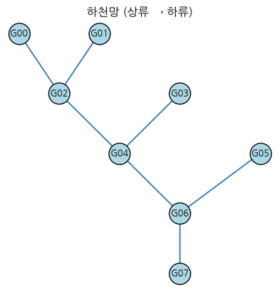

```python
# 하천망 그래프 그리기 (위치는 위상 순서로 손수 배치)
pos = {0: (0, 3), 1: (1, 3), 2: (0.5, 2), 3: (2, 2), 4: (1.25, 1), 5: (3, 1), 6: (2, 0), 7: (2, -1)}
fig, ax = plt.subplots(figsize=(5, 5))
for u, v in edge_index.T:
    ax.annotate("", xy=pos[v], xytext=pos[u],
                arrowprops=dict(arrowstyle="->", lw=1.5, color="steelblue"))
for i, g in enumerate(gauges):
    ax.scatter(*pos[i], s=500, c="lightblue", edgecolor="k", zorder=3)
    ax.text(*pos[i], g, ha="center", va="center", fontsize=9, zorder=4)
ax.set_axis_off(); ax.set_title("하천망 (상류 → 하류)"); plt.show()
```

## 5. 결측치 마스크: `mask` vs `eval_mask` vs `training_mask`

imputation 문제에서는 세 종류의 마스크가 등장합니다.

| 이름 | 의미 |
| --- | --- |
| `mask` | 원본 데이터에서 실제로 관측된 위치 (True = 관측) |
| `eval_mask` | **평가용으로 일부러 가린** 위치. 모델은 학습 시 이 값을 보지 못하고, 테스트 시 이 위치에서 오차를 계산 |
| `training_mask` | `mask & ~eval_mask` — 모델 입력으로 실제 사용되는 위치 |

`tsl.ops.imputation.add_missing_values()`가 `eval_mask`를 랜덤으로 만들어 데이터셋에 붙입니다(`MissingValuesMixin`). `p_fault`(연속 구간 결측 확률, 길이 `min_seq~max_seq`)와 `p_noise`(점 결측 확률)는 `default.yaml`의 `p_fault`, `p_noise`에 해당합니다.

```python
from tsl.ops.imputation import add_missing_values

ds = add_missing_values(ds, p_fault=0.0015, p_noise=0.05,
                        min_seq=12, max_seq=12 * 4, seed=42)

print(type(ds).__name__, "| eval_mask:", ds.eval_mask.shape)
print("관측 비율          :", ds.mask.mean().round(4))
print("eval_mask 비율     :", ds.eval_mask.mean().round(4))
print("training_mask 비율 :", ds.training_mask.mean().round(4))
```

```
MissingValuesHydrologyDataset | eval_mask: (2880, 8, 1)
관측 비율          : 0.9938
eval_mask 비율     : 0.0992
training_mask 비율 : 0.8945
```

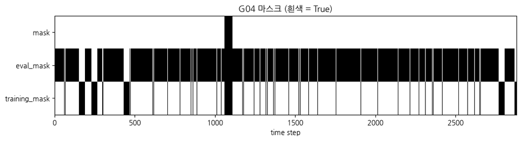

```python
fig, ax = plt.subplots(figsize=(12, 2.6))
node = 4
ax.imshow(np.stack([ds.mask[:, node, 0], ds.eval_mask[:, node, 0], ds.training_mask[:, node, 0]]),
          aspect="auto", cmap="Greys_r", interpolation="nearest")
ax.set_yticks([0, 1, 2]); ax.set_yticklabels(["mask", "eval_mask", "training_mask"])
ax.set_xlabel("time step"); ax.set_title(f"{gauges[node]} 마스크 (흰색 = True)"); plt.show()
```

## 6. `ImputationDataset`: torch 텐서 + 슬라이딩 윈도우

여기서부터 pandas → torch로 넘어갑니다. `ImputationDataset`은

- `target` `(T, N, C)`를 길이 `window`의 윈도우로 잘라 샘플을 만들고(`stride`만큼 이동),
- 각 샘플에 `x`(입력), `y`(정답), `mask`, `eval_mask`, `edge_index`, `edge_weight`, 공변량 `u`를 담은 `Data`(PyG `Data`의 확장)를 돌려줍니다.
- `transform=MaskInput()`은 `x`에서 `training_mask == False`인 값을 0으로 지웁니다(모델이 정답을 훔쳐보지 못하게).

공변량 `u`는 시각을 sin/cos로 인코딩한 것(`datetime_encoded('day')`)입니다. 예제 스크립트는 `(T, 2)` 전역 공변량을 그대로 넘기지만, 이 tsl 버전의 `GRINModel`은 노드별 공변량 `(T, N, F)`만 받습니다(`GRINCell`이 `[x, mask, h, u]`를 마지막 축으로 `cat`). 그래서 여기서는 같은 시각 인코딩을 노드 축으로 브로드캐스트해서 `(T, N, 2)`로 넘깁니다. tsl은 배열 형상에서 패턴(`t n f`)을 자동 추론합니다.

```python
from tsl.data import ImputationDataset
from tsl.transforms import MaskInput

day_enc = ds.datetime_encoded("day").values                        # (T, 2): day_sin, day_cos
covariates = {"u": np.repeat(day_enc[:, None, :], ds.n_nodes, axis=1)}   # (T, N, 2)

torch_dataset = ImputationDataset(target=ds.dataframe(),
                                  mask=ds.training_mask,
                                  eval_mask=ds.eval_mask,
                                  covariates=covariates,
                                  transform=MaskInput(),
                                  connectivity=(edge_index, edge_weight),
                                  window=24,
                                  stride=1)
print(torch_dataset)
```

```
ImputationDataset(n_samples=2857, n_nodes=8, n_channels=1)
```

```python
sample = torch_dataset[0]
print(sample)
print()
print("x  (window, nodes, channels):", tuple(sample.input.x.shape))
print("u  (window, nodes, exog)    :", tuple(sample.input.u.shape))
print("y  (window, nodes, channels):", tuple(sample.target.y.shape))
print("edge_index                  :", tuple(sample.edge_index.shape))
print()
print("input_map :", torch_dataset.input_map)
print("target_map:", torch_dataset.target_map)
```

```
Data(
  input=(x=[t=24, n=8, f=1], u=[t=24, n=8, f=2], mask=[t=24, n=8, f=1], edge_index=[2, e=7], edge_weight=[e=7]),
  target=(y=[t=24, n=8, f=1]),
  has_mask=True
)

x  (window, nodes, channels): (24, 8, 1)
u  (window, nodes, exog)    : (24, 8, 2)
y  (window, nodes, channels): (24, 8, 1)
edge_index                  : (2, 7)

input_map : BatchMap(
  'x': ([target], pattern='t n f', shape=(2880, 8, 1)),
  'u': ([u], pattern='t n f', shape=(2880, 8, 2)),
  'mask': ([mask], pattern='t n f', shape=(2880, 8, 1))
)
target_map: BatchMap(
  'y': ([target], pattern='t n f', shape=(2880, 8, 1))
)
```

## 7. `SpatioTemporalDataModule`: 스케일링 + 분할 + DataLoader

- `scalers={'target': StandardScaler(axis=(0, 1))}` — 시간·노드 축에 대해 채널별 표준화. 학습 구간 통계만 사용됩니다.
- `splitter=ds.get_splitter(val_len=0.1, test_len=0.2)` — 시간 순서대로 앞 70% 학습 / 10% 검증 / 뒤 20% 테스트 (`TemporalSplitter`). `spin_hydrology.yaml`의 `dataset.splitting`이 이 인자입니다.

```python
from tsl.data import SpatioTemporalDataModule
from tsl.data.preprocessing import StandardScaler

dm = SpatioTemporalDataModule(dataset=torch_dataset,
                              scalers={"target": StandardScaler(axis=(0, 1))},
                              splitter=ds.get_splitter(val_len=0.1, test_len=0.2),
                              batch_size=16,
                              workers=0)
dm.setup(stage="fit")
print(dm)
print("train/val/test 샘플 수:", len(dm.trainset), len(dm.valset), len(dm.testset))

batch = next(iter(dm.train_dataloader()))
print("\n배치 x shape (batch, window, nodes, channels):", tuple(batch.input.x.shape))
```

```
{Train dataloader: size=2034}
{Validation dataloader: size=204}
{Test dataloader: size=571}
{Predict dataloader: None}
train/val/test 샘플 수: 2034 204 571

배치 x shape (batch, window, nodes, channels): (16, 24, 8, 1)
```

## 8. `Imputer` + `GRINModel` 학습

`tsl.engines.Imputer`는 LightningModule입니다. 모델 클래스·옵티마이저·손실·지표를 받아 학습 루프를 처리하며, 특히

- `whiten_prob` — 학습 중 관측값을 추가로 무작위로 가려 자기지도(self-supervised) 신호를 만듭니다.
- `scale_target=True` — 손실을 스케일된 공간에서 계산.
- 손실 `MaskedMAE` — 마스크가 True인 위치만으로 평균 절대 오차를 계산합니다.

모델은 예제 스크립트의 `get_model_class()`에 있는 것 중 GRIN(그래프 순환 imputation 네트워크)을 사용합니다. `filter_model_args_()`는 모델 생성자가 받지 않는 키를 kwargs에서 제거해 주는 편의 함수입니다(예제 스크립트와 동일 패턴).

```python
from pytorch_lightning import Trainer, seed_everything
from pytorch_lightning.callbacks import EarlyStopping, ModelCheckpoint

from tsl.engines import Imputer
from tsl.nn.models import GRINModel
from tsl.metrics import torch as torch_metrics

seed_everything(0)

model_kwargs = dict(n_nodes=torch_dataset.n_nodes,
                    input_size=torch_dataset.n_channels,
                    exog_size=torch_dataset.input_map.u.shape[-1],
                    hidden_size=32, ff_size=64, embedding_size=8, n_layers=1)
GRINModel.filter_model_args_(model_kwargs)

imputer = Imputer(model_class=GRINModel,
                  model_kwargs=model_kwargs,
                  optim_class=torch.optim.Adam,
                  optim_kwargs={"lr": 1e-3},
                  loss_fn=torch_metrics.MaskedMAE(),
                  metrics={"mae": torch_metrics.MaskedMAE(),
                           "mre": torch_metrics.MaskedMRE(),
                           "mape": torch_metrics.MaskedMAPE()},
                  scale_target=True,
                  whiten_prob=0.05,
                  prediction_loss_weight=1.0,
                  impute_only_missing=False,
                  warm_up_steps=0)
imputer.model
```

```
Seed set to 0
```

```
GRINModel(
  (fwd_gril): GRINCell(input_size=1, hidden_size=32, kernel_size=2, n_layers=1)
  (bwd_gril): GRINCell(input_size=1, hidden_size=32, kernel_size=2, n_layers=1)
  (emb): NodeEmbedding(n_nodes=8, embedding_size=8)
  (out): Sequential(
    (0): Linear(in_features=137, out_features=64, bias=True)
    (1): ReLU()
    (2): Dropout(p=0.0, inplace=False)
    (3): Linear(in_features=64, out_features=1, bias=True)
  )
)
```

```python
LOG_DIR = os.path.join(REPO, "logs", "tutorial", "imputation")
os.makedirs(LOG_DIR, exist_ok=True)

checkpoint = ModelCheckpoint(dirpath=LOG_DIR, save_top_k=1, monitor="val_mae", mode="min")
trainer = Trainer(max_epochs=8,                     # 튜토리얼용으로 짧게. 실제 실험은 default.yaml의 300
                  default_root_dir=LOG_DIR,
                  logger=False,
                  accelerator="gpu" if torch.cuda.is_available() else "cpu",
                  devices=1,
                  gradient_clip_val=5.0,
                  callbacks=[EarlyStopping(monitor="val_mae", patience=5, mode="min"), checkpoint],
                  enable_progress_bar=False,
                  log_every_n_steps=10)
trainer.fit(imputer, datamodule=dm)
print("best checkpoint:", checkpoint.best_model_path)
```

[output not shown]

```
┏━━━┳━━━━━━━━━━━━━━━┳━━━━━━━━━━━━━━━━━━┳━━━━━━━━┳━━━━━━━┳━━━━━━━┓
┃   ┃ Name          ┃ Type             ┃ Params ┃ Mode  ┃ FLOPs ┃
┡━━━╇━━━━━━━━━━━━━━━╇━━━━━━━━━━━━━━━━━━╇━━━━━━━━╇━━━━━━━╇━━━━━━━┩
│ 0 │ loss_fn       │ MaskedMAE        │      0 │ train │     0 │
│ 1 │ train_metrics │ MetricCollection │      0 │ train │     0 │
│ 2 │ val_metrics   │ MetricCollection │      0 │ train │     0 │
│ 3 │ test_metrics  │ MetricCollection │      0 │ train │     0 │
│ 4 │ model         │ GRINModel        │ 55.1 K │ train │     0 │
└───┴───────────────┴──────────────────┴────────┴───────┴───────┘
```

```
Trainable params: 55.1 K
Non-trainable params: 0
Total params: 55.1 K
Total estimated model params size (MB): 0.220
Modules in train mode: 70
Modules in eval mode: 0
Total FLOPs: 0
```

```
Only args ['edge_weight', 'edge_index', 'mask', 'u', 'x'] are forwarded to the model (GRINModel).
`Trainer.fit` stopped: `max_epochs=8` reached.
```

```
best checkpoint: /home/hydro/research/gnn/HydroTGNN/logs/tutorial/imputation/epoch=3-step=508-v2.ckpt
```

## 9. 평가와 시각화

예제 스크립트와 같은 순서입니다: best checkpoint 로드 → `trainer.test` → `trainer.predict`로 출력 수집 → numpy 지표로 재계산. `eval_mask`가 True인(일부러 가린) 위치에서만 오차를 계산한다는 점이 핵심입니다.

```python
from tsl.metrics import numpy as numpy_metrics
from tsl.utils.casting import torch_to_numpy

imputer.load_model(checkpoint.best_model_path)
imputer.freeze()
test_res = trainer.test(imputer, datamodule=dm, verbose=False)[0]

output = trainer.predict(imputer, dataloaders=dm.test_dataloader())
output = torch_to_numpy(imputer.collate_prediction_outputs(output))
y_hat, y_true, ev_mask = output["y_hat"], output["y"], output["eval_mask"]
print("y_hat shape (samples, window, nodes, channels):", y_hat.shape)

res = dict(test_mae=numpy_metrics.mae(y_hat, y_true, ev_mask),
           test_mre=numpy_metrics.mre(y_hat, y_true, ev_mask),
           test_mape=numpy_metrics.mape(y_hat, y_true, ev_mask))
pd.Series({**test_res, **res}).round(4)
```

```
LOCAL_RANK: 0 - CUDA_VISIBLE_DEVICES: [0]
LOCAL_RANK: 0 - CUDA_VISIBLE_DEVICES: [0]
```

```
y_hat shape (samples, window, nodes, channels): (571, 24, 8, 1)
```

```
test_mae     5.6646
test_mape    0.1245
test_mre     0.1109
test_loss    1.5924
dtype: float64
```

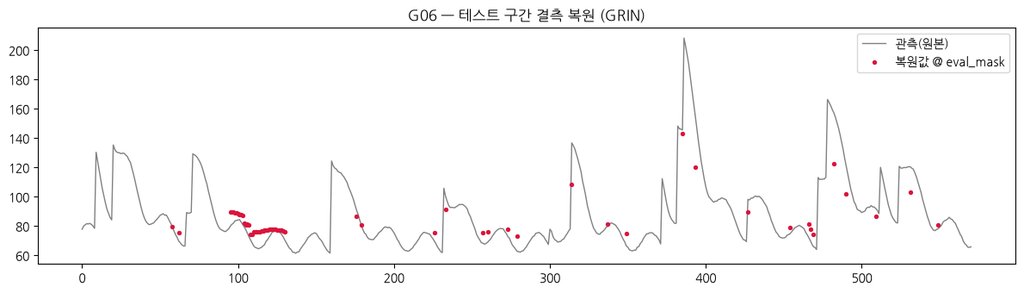

```python
# 테스트 구간의 한 노드에서, 가려진 값(eval_mask)의 복원 결과를 보기
# stride=1 이므로 샘플 i의 윈도우 첫 스텝이 테스트 구간의 i번째 시각. 각 윈도우의 첫 스텝만 이어 붙임.
node = 6
yh = y_hat[:, 0, node, 0]; yt = y_true[:, 0, node, 0]; em = ev_mask[:, 0, node, 0].astype(bool)
tt = np.arange(len(yh))

fig, ax = plt.subplots(figsize=(12, 3.5))
ax.plot(tt, yt, color="gray", lw=1, label="관측(원본)")
ax.scatter(tt[em], yh[em], s=8, color="crimson", label="복원값 @ eval_mask", zorder=3)
ax.set_title(f"{gauges[node]} — 테스트 구간 결측 복원 (GRIN)"); ax.legend(); plt.tight_layout(); plt.show()
```

## 10. (보너스) 예측(forecasting) 파이프라인

같은 데이터셋으로 *미래 유량 예측*을 하려면 `ImputationDataset` 대신 `SpatioTemporalDataset(window, horizon)`, `Imputer` 대신 `Predictor`를 쓰고, 예측 모델(예: `DCRNNModel`)을 넣으면 됩니다. 나머지(DataModule, Trainer)는 동일합니다. `tsl/examples/forecasting/run_traffic_experiment.py`가 이 경로의 전체 예제입니다.

```python
from tsl.data import SpatioTemporalDataset
from tsl.engines import Predictor
from tsl.nn.models import DCRNNModel

fc_dataset = SpatioTemporalDataset(target=ds.dataframe(),
                                   mask=ds.mask,                 # 관측된 값만 손실 계산에 사용
                                   covariates=covariates,
                                   connectivity=(edge_index, edge_weight),
                                   window=24,                    # 과거 24시간을 보고
                                   horizon=6)                    # 6시간 앞을 예측
fc_dm = SpatioTemporalDataModule(dataset=fc_dataset,
                                 scalers={"target": StandardScaler(axis=(0, 1))},
                                 splitter=ds.get_splitter(val_len=0.1, test_len=0.2),
                                 batch_size=16, workers=0)
fc_dm.setup(stage="fit")

fc_kwargs = dict(input_size=fc_dataset.n_channels,
                 output_size=fc_dataset.n_channels,
                 horizon=fc_dataset.horizon,
                 exog_size=fc_dataset.input_map.u.shape[-1],
                 hidden_size=32, n_layers=1)
predictor = Predictor(model_class=DCRNNModel, model_kwargs=fc_kwargs,
                      optim_class=torch.optim.Adam, optim_kwargs={"lr": 1e-3},
                      loss_fn=torch_metrics.MaskedMAE(),
                      metrics={"mae": torch_metrics.MaskedMAE(),
                               "mae_at_6h": torch_metrics.MaskedMAE(at=5)},
                      scale_target=True)

fc_trainer = Trainer(max_epochs=5, logger=False, enable_checkpointing=False,
                     accelerator="gpu" if torch.cuda.is_available() else "cpu", devices=1,
                     gradient_clip_val=5.0, enable_progress_bar=False, log_every_n_steps=10)
fc_trainer.fit(predictor, datamodule=fc_dm)
pd.Series(fc_trainer.test(predictor, datamodule=fc_dm, verbose=False)[0]).round(4)
```

```
GPU available: True (cuda), used: True
TPU available: False, using: 0 TPU cores
💡 Tip: For seamless cloud logging and experiment tracking, try installing [litlogger](https://pypi.org/project/litlogger/) to enable LitLogger, which logs metrics and artifacts automatically to the Lightning Experiments platform.
LOCAL_RANK: 0 - CUDA_VISIBLE_DEVICES: [0]
```

```
┏━━━┳━━━━━━━━━━━━━━━┳━━━━━━━━━━━━━━━━━━┳━━━━━━━━┳━━━━━━━┳━━━━━━━┓
┃   ┃ Name          ┃ Type             ┃ Params ┃ Mode  ┃ FLOPs ┃
┡━━━╇━━━━━━━━━━━━━━━╇━━━━━━━━━━━━━━━━━━╇━━━━━━━━╇━━━━━━━╇━━━━━━━┩
│ 0 │ loss_fn       │ MaskedMAE        │      0 │ train │     0 │
│ 1 │ train_metrics │ MetricCollection │      0 │ train │     0 │
│ 2 │ val_metrics   │ MetricCollection │      0 │ train │     0 │
│ 3 │ test_metrics  │ MetricCollection │      0 │ train │     0 │
│ 4 │ model         │ DCRNNModel       │ 43.0 K │ train │     0 │
└───┴───────────────┴──────────────────┴────────┴───────┴───────┘
```

```
Trainable params: 43.0 K
Non-trainable params: 0
Total params: 43.0 K
Total estimated model params size (MB): 0.172
Modules in train mode: 39
Modules in eval mode: 0
Total FLOPs: 0
```

```
Only args ['edge_index', 'u', 'x', 'edge_weight'] are forwarded to the model (DCRNNModel).
`Trainer.fit` stopped: `max_epochs=5` reached.
LOCAL_RANK: 0 - CUDA_VISIBLE_DEVICES: [0]
```

```
test_mae          2.5543
test_mae_at_6h    3.5715
test_loss         2.5543
dtype: float64
```

```
LOCAL_RANK: 0 - CUDA_VISIBLE_DEVICES: [0]
```

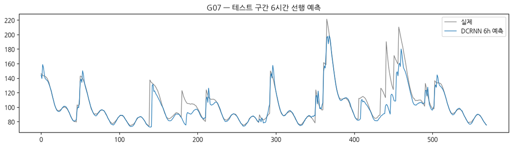

```python
out = torch_to_numpy(predictor.collate_prediction_outputs(
    fc_trainer.predict(predictor, dataloaders=fc_dm.test_dataloader())))
node, h = 7, 5      # 최하류 관측소, 6시간 앞(horizon index 5)
fig, ax = plt.subplots(figsize=(12, 3.5))
ax.plot(out["y"][:, h, node, 0], color="gray", lw=1, label="실제")
ax.plot(out["y_hat"][:, h, node, 0], color="tab:blue", lw=1, label="DCRNN 6h 예측")
ax.set_title(f"{gauges[node]} — 테스트 구간 6시간 선행 예측"); ax.legend(); plt.tight_layout(); plt.show()
```

## 11. Hydra 설정(`spin_hydrology.yaml`)과 예제 스크립트 연결하기

`spin_hydrology.yaml`은 `tsl/examples/imputation/config/default.yaml` 위에 덮어쓰는 설정입니다(`defaults: [default, _self_]`). 그러나 현재 상태로는 실행되지 않습니다:

1. `run_imputation_experiment.py`의 `get_dataset()`은 `air*`, `la`, `bay` 이름만 알고, `hydrology`는 `ValueError`를 냅니다.
2. yaml의 데이터 경로가 Windows 절대경로(`E:/...`)입니다.

이 노트북에서 만든 `HydrologyDataset`을 스크립트에 연결하려면 `get_dataset()`에 아래 분기를 추가하면 됩니다 (`cfg.dataset`을 통째로 넘기도록 호출부도 한 줄 바꿉니다):

```
# run_imputation_experiment.py
from hydrology_dataset import HydrologyDataset      # 이 노트북의 서브클래스를 파일로 옮긴 경우

def get_dataset(dataset_cfg, p_fault=0., p_noise=0.):
    name = dataset_cfg.name
    if name == 'hydrology':
        ds = HydrologyDataset(dataset_cfg.adj_matrix_path,
                              dataset_cfg.discharge_data_path)
        return add_missing_values(ds, p_fault=p_fault, p_noise=p_noise,
                                  min_seq=12, max_seq=12 * 4, seed=42)
    ...

# run_imputation() 안에서
dataset = get_dataset(cfg.dataset, p_fault=cfg.get('p_fault'), p_noise=cfg.get('p_noise'))
```

그리고 yaml을 config 디렉터리에 두고 경로를 덮어써서 실행합니다:

```
cp spin_hydrology.yaml tsl/examples/imputation/config/
cd tsl/examples/imputation
python run_imputation_experiment.py config=spin_hydrology \
    dataset.adj_matrix_path=$PWD/../../../data/synthetic/adj_matrix.csv \
    dataset.discharge_data_path=$PWD/../../../data/synthetic/merged_discharge_data.csv
```

결과는 `logs/imputation/spin/<날짜>/<시각>/`에 저장됩니다(`hydra.run.dir`).

## 요약

| 단계 | 객체 | 이 저장소에서의 위치 |
| --- | --- | --- |
| CSV → pandas 데이터셋 | `IJCNNHydrologyDataset` | `hydrology_dataset.py` |
| 그래프 만들기 | `get_connectivity()` ← `compute_similarity()` | `dataset.connectivity` in yaml |
| 평가용 결측 주입 | `add_missing_values()` | `p_fault`, `p_noise` in `default.yaml` |
| 윈도우 샘플링 | `ImputationDataset` / `SpatioTemporalDataset` | `window`, `stride` in yaml |
| 스케일·분할 | `SpatioTemporalDataModule` | `dataset.splitting`, `batch_size` |
| 학습 엔진 | `Imputer` / `Predictor` + 모델 | `model.name`, `model.hparams` |
| 실행 | `Experiment` (Hydra) | `run_imputation_experiment.py` |